# HM_ClassNotes_23January2018

C. Merriman

January 23, 2018

## REVIEW:

All models have stochastic part and deterministic part. QUESTION: We ended last week with catfish survival data

```r
catsurf<-read.csv("catfish_survival.csv")
plot(catsurf$catfish_survival~catsurf$water_depth)
#glm = GENERLALIZED linear model
#parameterized using maximum liklihood estimate (MLE)
#find the value of p that results in MLE
catmod1<-glm(catfish_survival~water_depth, data=catsurf, family=binomial)
coef(catmod1) #calling only the coefficients...these corroborate with rest of the class
```

```
## (Intercept) water_depth
##   0.2177667   0.5563107
```

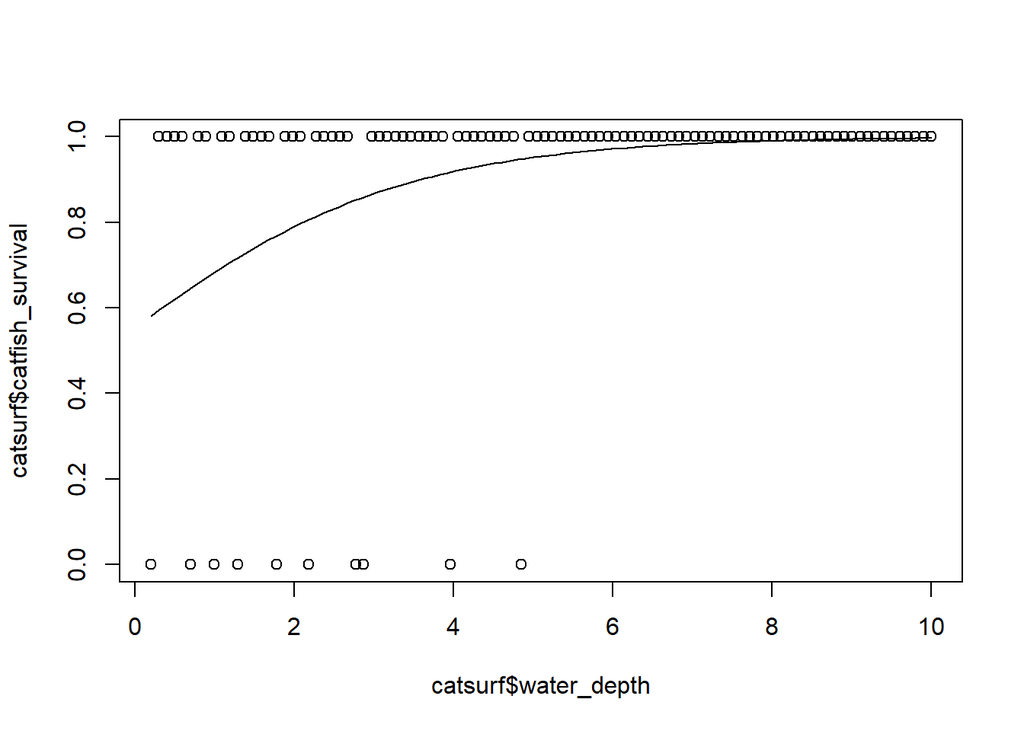

```r
plot(catsurf$catfish_survival~catsurf$water_depth)
curve(plogis(0.2177667+0.553107*x), add=T)
```

The above is how you would interpret parameters if it was a linear model.

BUT as a consequence of logit-link, the parameters are on the real number scale. To interpret, we need to transform to the probability scale. This makes for an importat change because it accounts for the 0-1 scale that binary response variables may need.

QUESTION: How can we interpret these parameters? Intercept= 0.2177667 <- Baseline survival when water depth is near zero. Put on a probability scale using plogis(intercept) Baseline survival for catfish: logistic(0.21777) Slope: trickier versus a normal linear regression because not linear. At beginning: not a lot of effect IN middle: big effect At end: not a lot of effect Trick: Divide by Four RUle: Value of the derivative at the steepest part of the line< this means a fair amount of calculus, which essentiallly breaks down into the slope parameter divided by four. ((be<sup>0)/((1+e</sup>0)^2))=(b/4) Soooo….effect of water depth is ~ 0.56/4=0.14. By increasing water depth by 1 unit we see a 14% increase in catfish survival.

ANOTHER WAY TO DO THIS: evaluate how probability is different between values of x. If the intercept is 0.5, and slope is 0.1, we can calculate difference between two values of x:

```r
x1<-2
x2<-0
print("Difference between a value of x=2 and x=0:")
```

```
## [1] "Difference between a value of x=2 and x=0:"
```

```r
plogis(0.5+0.1*x1)-plogis(0.5+0.1*x2)
```

```
## [1] 0.04572844
```

This is another way to talk about effect size. See example on hunting/logging on animals…Roopsind et al 2017.

### HYPOTHESIS TESTS: LOGISTIC REGRESSION

Look at confidence intervals for catfish

```r
confint(catmod1) #corroborates with class
```

```
##                  2.5 %   97.5 %
## (Intercept) -0.9432583 1.403034
## water_depth  0.2320441 1.001251
```

But is this really that handy? We want o interpret this on the REAL Number scale. EFFECT SIZE: Put on probability scale HYP. TEST: Put on Real number scale